# Capstone_NLP2_Chatbot_Group7

**PROBLEM STATEMENT**

• **DOMAIN:** Industrial safety. NLP based Chatbot.

• **CONTEXT:**

The database comes from one of the biggest industry in Brazil and in the world. It is an urgent need for industries/companies around the globe to understand why employees still suffer some injuries/accidents in plants. Sometimes they also die in such environment.

• **DATA DESCRIPTION:** This The database is basically records of accidents from 12 different plants in 03 different countries which every line in the data is an occurrence of an accident. Columns description: ‣ Data: timestamp or time/date information ‣ Countries: which country the accident occurred (anonymised) ‣ Local: the city where the manufacturing plant is located (anonymised) ‣ Industry sector: which sector the plant belongs to ‣ Accident level: from I to VI, it registers how severe was the accident (I means not severe but VI means very severe) ‣ Potential Accident Level: Depending on the Accident Level, the database also registers how severe the accident could have been (due to other factors involved in the accident) ‣ Gender: if the person is male of female ‣ Employee or Third Party: if the injured person is an employee or a third party ‣ Critical Risk: some description of the risk involved in the accident ‣ Description: Detailed description of how the accident happened. Link to download the dataset: https://drive.google.com/file/d/1_GmrRP1S2OIa02KlfOBNkYa8uxazGbfE/view?usp=sharing, Original dataset link: https://www.kaggle.com/ihmstefanini/industrial-safety-and-health-analytics-database

**• PROJECT OBJECTIVE:** Design a ML/DL based chatbot utility which can help the professionals to highlight the safety risk as per the incident description.

**• PROJECT TASK:** [ Duration: 6 weeks, Score: 100 points]

1. **Milestone 1:** [ Duration: 2 weeks, Score: 20 points] ‣ Input: Interim report ‣ Process: ‣ Step 1: Import the data ‣ Step 2: Data cleansing ‣ Step 3: Data preprocessing ‣ Step 4: Data preparation to be used for AIML model learning ‣ Output: Clean data as .xlsx or .csv file to be used for AIML model learning

2. **Milestone 2:** [ Duration: 2 weeks, Score: 20 points] ‣ Input: Output of milestone 1 ‣ Process: ‣ Step 1: NLP pre processing ‣ Step 2: Design, train and test machine learning classifiers ‣ Step 3: Design, train and test Neural networks classifiers ‣ Step 4: Design, train and test RNN or LSTM classifiers ‣ Step 5: Choose the best performing model classifier and pickle it. ‣ Output: Pickled model to be used for future prediction ‣ Submission: Interim report

1. Milestone 3: [ Duration: 2 weeks, Score: 60 points] ‣ Input: Pickled model from milestone 2 ‣ Process: [ 15 points ] ‣ Step 1: Design a clickable UI which can automate tasks performed under milestone 1 [ 5 points ] ‣ Step 2: Design a clickable UI which can automate tasks performed under milestone 2 [ 5 points ] ‣ Step 3: Design a clickable UI based chatbot interface [ 5 points ] ‣ Output: Clickable UI based chatbot interface which accepts text as input and replies back with relevant answers. ‣ Submission: Final report [ 45 points ]

# Import libraries

```python
from google.colab import drive
drive.mount('/content/drive', force_remount=True)
```

```python
##  setting paths
import sys
import os

py_file_location = "/content/drive/MyDrive/jupyter/capstone"
sys.path.append(os.path.abspath(py_file_location))
```

```python
import tensorflow as tf
tf.__version__
```

```
'2.7.0'
```

```python
import numpy as np
import pandas as pd
import seaborn as sns
import matplotlib.pyplot as plt
import plotly.express as px
from plotly import graph_objs as go
import plotly.figure_factory as ff
import nltk
from nltk.util import ngrams
nltk.download('vader_lexicon')
nltk.download('punkt')
nltk.download('wordnet')
# nltk.download('stopwords')
from nltk import tokenize,stem
from nltk.sentiment.vader import SentimentIntensityAnalyzer
from wordcloud import WordCloud, STOPWORDS
# stop_words = stopwords.words('english')
import random, re
import time
from tqdm import tqdm
from sklearn.feature_extraction.text import TfidfVectorizer

from scipy.stats import randint as sp_randint

# pre-processing methods
from sklearn.preprocessing import StandardScaler
from sklearn.preprocessing import PowerTransformer
from sklearn.preprocessing import LabelEncoder
from sklearn.model_selection import train_test_split

from sklearn.pipeline import Pipeline
from sklearn.decomposition import PCA
from sklearn.decomposition import TruncatedSVD
from sklearn.discriminant_analysis import LinearDiscriminantAnalysis
from sklearn.feature_selection import SelectKBest
from sklearn.feature_selection import f_classif
from sklearn.feature_selection import mutual_info_classif
from sklearn.feature_selection import RFE
from sklearn.feature_selection import RFECV

# sampling methods
from imblearn.over_sampling import SMOTE

# the classification models
from sklearn.linear_model import LogisticRegression
from sklearn.linear_model import RidgeClassifier
from sklearn.linear_model import Lasso
from sklearn.neighbors import KNeighborsClassifier
from sklearn.naive_bayes import GaussianNB
from sklearn.svm import SVC
from sklearn.tree import DecisionTreeClassifier

# ensemble models
from sklearn.ensemble import RandomForestClassifier
from sklearn.ensemble import StackingClassifier
from sklearn.ensemble import BaggingClassifier
from sklearn.ensemble import ExtraTreesClassifier
from sklearn.ensemble import AdaBoostClassifier
from sklearn.ensemble import GradientBoostingClassifier
# from catboost import CatBoostClassifier
from lightgbm import LGBMClassifier
from xgboost import XGBClassifier

# methods and classes for evaluation
from sklearn.model_selection import cross_val_score
from sklearn.model_selection import StratifiedKFold

from sklearn import metrics
from sklearn.metrics import classification_report
from sklearn.metrics import accuracy_score, f1_score, confusion_matrix, recall_score, precision_score, roc_auc_score

# cross-validation methods
from sklearn.model_selection import KFold
from sklearn.model_selection import RepeatedStratifiedKFold
from sklearn.model_selection import GridSearchCV, RandomizedSearchCV

tf.get_logger().setLevel('ERROR')
# Deep learning libraries
from keras.utils import np_utils
from keras.layers import Input
from keras.layers.merge import Concatenate
#from keras.optimizers import SGD
from tensorflow.keras.models import Sequential
from tensorflow.keras import optimizers
from keras.models import Model
from tensorflow.keras.layers import Flatten, Activation, Dense, LSTM, BatchNormalization, Embedding, Dropout, Flatten, Bidirectional, GlobalMaxPool1D
from keras.models import model_from_json
from keras.regularizers import l1, l2, l1_l2
from keras.constraints import maxnorm, min_max_norm
from keras.constraints import unit_norm

## import py
from utility import *

# Deep learning libraries
from keras.utils import np_utils
from keras.utils.vis_utils import plot_model
from keras.layers import Input
from keras.layers.merge import Concatenate
from tensorflow.keras.optimizers import SGD
from tensorflow.keras.models import Sequential
from tensorflow.keras import optimizers
from keras.models import Model
from tensorflow.keras.layers import Flatten, Activation, Dense, LSTM, BatchNormalization, Embedding, Dropout, Flatten, Bidirectional, GlobalMaxPool1D
from keras.models import model_from_json
from keras.regularizers import l1, l2, l1_l2
from keras.constraints import maxnorm, min_max_norm
from keras.constraints import unit_norm
from keras.callbacks import ReduceLROnPlateau
from keras.callbacks import EarlyStopping
from keras.callbacks import ModelCheckpoint
from keras.models import model_from_json

from keras.models import load_model
from keras.wrappers.scikit_learn import KerasClassifier

# Keras pre-processing
from tensorflow.keras.preprocessing.text import Tokenizer
from tensorflow.keras.preprocessing.sequence import pad_sequences

## Ignore warning
import warnings
warnings.filterwarnings("ignore")
```

# Import the data

```python
df = pd.read_csv("/content/drive/MyDrive/jupyter/capstone/Data Set - industrial_safety_and_health_database_with_accidents_description.csv")
df.head(3)
```

|  | Unnamed: 0 | Data | Countries | Local | Industry Sector | Accident Level | Potential Accident Level | Genre | Employee or Third Party | Critical Risk | Description |
| --- | --- | --- | --- | --- | --- | --- | --- | --- | --- | --- | --- |
| 0 | 0 | 2016-01-01 00:00:00 | Country_01 | Local_01 | Mining | I | IV | Male | Third Party | Pressed | While removing the drill rod of the Jumbo 08 f... |
| 1 | 1 | 2016-01-02 00:00:00 | Country_02 | Local_02 | Mining | I | IV | Male | Employee | Pressurized Systems | During the activation of a sodium sulphide pum... |
| 2 | 2 | 2016-01-06 00:00:00 | Country_01 | Local_03 | Mining | I | III | Male | Third Party (Remote) | Manual Tools | In the sub-station MILPO located at level +170... |

```python
## Drop Unnamed colum & rename other columns
df.drop("Unnamed: 0", axis=1, inplace=True)
df.rename(columns={'Data':'Date', 'Countries':'Country', 'Genre':'Gender', 'Employee or Third Party':'Employee type'}, inplace=True)
df.head(3)
```

|  | Date | Country | Local | Industry Sector | Accident Level | Potential Accident Level | Gender | Employee type | Critical Risk | Description |
| --- | --- | --- | --- | --- | --- | --- | --- | --- | --- | --- |
| 0 | 2016-01-01 00:00:00 | Country_01 | Local_01 | Mining | I | IV | Male | Third Party | Pressed | While removing the drill rod of the Jumbo 08 f... |
| 1 | 2016-01-02 00:00:00 | Country_02 | Local_02 | Mining | I | IV | Male | Employee | Pressurized Systems | During the activation of a sodium sulphide pum... |
| 2 | 2016-01-06 00:00:00 | Country_01 | Local_03 | Mining | I | III | Male | Third Party (Remote) | Manual Tools | In the sub-station MILPO located at level +170... |

```python
df.isna().sum()
```

```
Date                        0
Country                     0
Local                       0
Industry Sector             0
Accident Level              0
Potential Accident Level    0
Gender                      0
Employee type               0
Critical Risk               0
Description                 0
dtype: int64
```

```python
df.describe()
```

|  | Date | Country | Local | Industry Sector | Accident Level | Potential Accident Level | Gender | Employee type | Critical Risk | Description |
| --- | --- | --- | --- | --- | --- | --- | --- | --- | --- | --- |
| count | 425 | 425 | 425 | 425 | 425 | 425 | 425 | 425 | 425 | 425 |
| unique | 287 | 3 | 12 | 3 | 5 | 6 | 2 | 3 | 33 | 411 |
| top | 2017-02-08 00:00:00 | Country_01 | Local_03 | Mining | I | IV | Male | Third Party | Others | During the activity of chuteo of ore in hopper... |
| freq | 6 | 251 | 90 | 241 | 316 | 143 | 403 | 189 | 232 | 3 |

```python
df.info()
```

```
<class 'pandas.core.frame.DataFrame'>
RangeIndex: 425 entries, 0 to 424
Data columns (total 10 columns):
 #   Column                    Non-Null Count  Dtype
---  ------                    --------------  -----
 0   Date                      425 non-null    object
 1   Country                   425 non-null    object
 2   Local                     425 non-null    object
 3   Industry Sector           425 non-null    object
 4   Accident Level            425 non-null    object
 5   Potential Accident Level  425 non-null    object
 6   Gender                    425 non-null    object
 7   Employee type             425 non-null    object
 8   Critical Risk             425 non-null    object
 9   Description               425 non-null    object
dtypes: object(10)
memory usage: 33.3+ KB
```

```python
# generate count statistics of duplicate entries
if len(df[df.duplicated()]) > 0:
    print("No. of duplicated entries: ", len(df[df.duplicated()]))
    display(df[df.duplicated(keep=False)].sort_values(by=list(df.columns)).head())
else:
    print("No duplicated entries found")
```

```
No. of duplicated entries:  7
```

|  | Date | Country | Local | Industry Sector | Accident Level | Potential Accident Level | Gender | Employee type | Critical Risk | Description |
| --- | --- | --- | --- | --- | --- | --- | --- | --- | --- | --- |
| 76 | 2016-04-01 00:00:00 | Country_01 | Local_01 | Mining | I | V | Male | Third Party (Remote) | Others | In circumstances that two workers of the Abrat... |
| 77 | 2016-04-01 00:00:00 | Country_01 | Local_01 | Mining | I | V | Male | Third Party (Remote) | Others | In circumstances that two workers of the Abrat... |
| 261 | 2016-12-01 00:00:00 | Country_01 | Local_03 | Mining | I | IV | Male | Employee | Others | During the activity of chuteo of ore in hopper... |
| 262 | 2016-12-01 00:00:00 | Country_01 | Local_03 | Mining | I | IV | Male | Employee | Others | During the activity of chuteo of ore in hopper... |
| 302 | 2017-01-21 00:00:00 | Country_02 | Local_02 | Mining | I | I | Male | Third Party (Remote) | Others | Employees engaged in the removal of material f... |

```python
# Removing duplicate entries
df.drop_duplicates(inplace=True)
```

```python
def find_unique_values_count(dataframe) :
    for column in dataframe :
         print("Unique value in column ", column , " is ", len(dataframe[column].unique()))
         z=pd.DataFrame(dataframe[column].value_counts()).reset_index()
         z.columns = ['Unique value','Count']
         display(z)
         print("############################################################################\n")
```

```python
find_unique_values_count(df[{"Country","Local","Industry Sector","Accident Level","Potential Accident Level","Gender","Employee type"}])
```

```
Unique value in column  Employee type  is  3
```

|  | Unique value | Count |
| --- | --- | --- |
| 0 | Third Party | 185 |
| 1 | Employee | 178 |
| 2 | Third Party (Remote) | 55 |

```
############################################################################

Unique value in column  Accident Level  is  5
```

|  | Unique value | Count |
| --- | --- | --- |
| 0 | I | 309 |
| 1 | II | 40 |
| 2 | III | 31 |
| 3 | IV | 30 |
| 4 | V | 8 |

```
############################################################################

Unique value in column  Local  is  12
```

|  | Unique value | Count |
| --- | --- | --- |
| 0 | Local_03 | 89 |
| 1 | Local_05 | 59 |
| 2 | Local_01 | 56 |
| 3 | Local_04 | 55 |
| 4 | Local_06 | 46 |
| 5 | Local_10 | 41 |
| 6 | Local_08 | 27 |
| 7 | Local_02 | 23 |
| 8 | Local_07 | 14 |
| 9 | Local_12 | 4 |
| 10 | Local_09 | 2 |
| 11 | Local_11 | 2 |

```
############################################################################

Unique value in column  Gender  is  2
```

|  | Unique value | Count |
| --- | --- | --- |
| 0 | Male | 396 |
| 1 | Female | 22 |

```
############################################################################

Unique value in column  Industry Sector  is  3
```

|  | Unique value | Count |
| --- | --- | --- |
| 0 | Mining | 237 |
| 1 | Metals | 134 |
| 2 | Others | 47 |

```
############################################################################

Unique value in column  Country  is  3
```

|  | Unique value | Count |
| --- | --- | --- |
| 0 | Country_01 | 248 |
| 1 | Country_02 | 129 |
| 2 | Country_03 | 41 |

```
############################################################################

Unique value in column  Potential Accident Level  is  6
```

|  | Unique value | Count |
| --- | --- | --- |
| 0 | IV | 141 |
| 1 | III | 106 |
| 2 | II | 95 |
| 3 | I | 45 |
| 4 | V | 30 |
| 5 | VI | 1 |

```
############################################################################
```

Identify the Critical Risk for "Others" type.

# Pre-processing

- Accidents can happen throughout the year, but maybe more prevalant during a specific period, so adding date and time features like year,month and day.

```python
df['Date'] = pd.to_datetime(df['Date'])
df['Year'] = df['Date'].apply(lambda x : x.year)
df['Month'] = df['Date'].apply(lambda x : x.month)
df['Day'] = df['Date'].apply(lambda x : x.day)
df['Weekday'] = df['Date'].apply(lambda x : x.day_name())
df['WeekofYear'] = df['Date'].apply(lambda x : x.weekofyear)
df.head(2)
```

|  | Date | Country | Local | Industry Sector | Accident Level | Potential Accident Level | Gender | Employee type | Critical Risk | Description | Year | Month | Day | Weekday | WeekofYear |
| --- | --- | --- | --- | --- | --- | --- | --- | --- | --- | --- | --- | --- | --- | --- | --- |
| 0 | 2016-01-01 | Country_01 | Local_01 | Mining | I | IV | Male | Third Party | Pressed | While removing the drill rod of the Jumbo 08 f... | 2016 | 1 | 1 | Friday | 53 |
| 1 | 2016-01-02 | Country_02 | Local_02 | Mining | I | IV | Male | Employee | Pressurized Systems | During the activation of a sodium sulphide pum... | 2016 | 1 | 2 | Saturday | 53 |

# EDA

## Univariate Analysis

### Country Wise Distribution

```python
def createPieChart(df, column_name, title, width, height):
  fig = plt.figure(figsize=(width,height))
  ax = fig.add_axes([0,0,1,1])
  ax.axis('equal')
  labels = df[column_name].unique()
  values = list(df[column_name].value_counts())
  ax.pie(values, labels = labels, autopct='%1.2f%%')
  plt.title(title)
  plt.show()
```

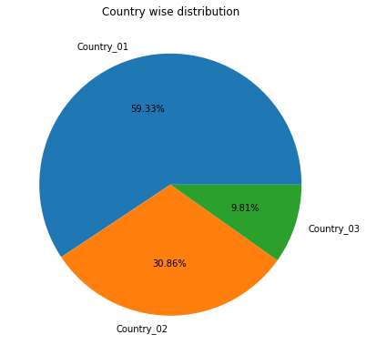

```python
createPieChart(df,'Country','Country wise distribution', 5, 5)
```

- Country_01 has more accident records.

### Local

[figure not shown]

```python
createPieChart(df,'Local','Local (city) wise distribution', 8, 8)
```

```python
df[df['Local'] == 'Local_03'].Country.value_counts()
```

```
Country_01    89
Name: Country, dtype: int64
```

- Most of accidents are reported in Local_03 which belongs to Country_01.

### Industry Sector

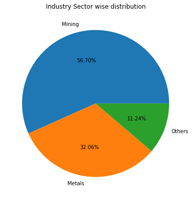

```python
createPieChart(df,'Industry Sector','Industry Sector wise distribution', 5, 5)
```

```python
print(df[df['Industry Sector'] == 'Mining'].Country.value_counts())
print(df[df['Industry Sector'] == 'Mining'].Local.value_counts())
```

```
Country_01    200
Country_02     37
Name: Country, dtype: int64
Local_03    89
Local_01    56
Local_04    55
Local_02    23
Local_07    14
Name: Local, dtype: int64
```

- Most of accidents are belongs to mining sector reported in Local_03 which belongs to Country_01.

### Accident Levels

```python
## Mapped Accident level & Potential Accident level to numeric
level_dct = {'I': 1,
       'II': 2,
       'III': 3,
       'IV': 4,
       'V': 5,
       'VI': 6}
df['Accident_Level_mapped'] = df['Accident Level'].replace(level_dct)
df['Potential_Accident_Level_mapped'] = df['Potential Accident Level'].replace(level_dct)
```

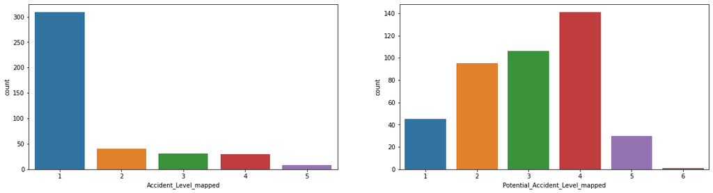

```python
fig,ax = plt.subplots(nrows=1,ncols=2,figsize=(20,5))
acc_level = "Accident_Level_mapped"
sns.countplot(data=df,x=acc_level,ax=ax[0])

pot_acc_level = "Potential_Accident_Level_mapped"
sns.countplot(data=df,x=pot_acc_level,ax=ax[1])

plt.show()
```

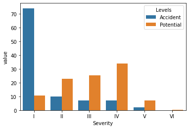

```python
ac_level_cnt = np.round(df['Accident Level'].value_counts(normalize=True) * 100)
pot_ac_level_cnt = np.round(df['Potential Accident Level'].value_counts(normalize=True) * 100, decimals=1)
ac_pot = pd.concat([ac_level_cnt, pot_ac_level_cnt], axis=1,sort=False).fillna(0).rename(columns={'Accident Level':'Accident', 'Potential Accident Level':'Potential'})
ac_pot = pd.melt(ac_pot.reset_index(), ['index']).rename(columns={'index':'Severity', 'variable':'Levels'})

sns.barplot(x="Severity", y="value", hue="Levels", data=ac_pot)
```

- Less severe accidents are more frequent.

### Gender

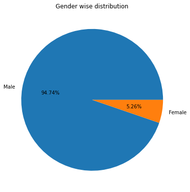

```python
createPieChart(df,'Gender','Gender wise distribution', 5, 5)
```

- Proportion of men is significantly higher as per the industry sector.

### Employee type

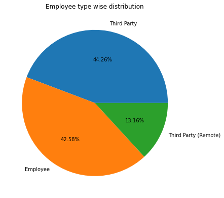

```python
createPieChart(df,'Employee type','Employee type wise distribution', 5, 5)
```

The large number of Third Party employee including remote type are more prone to accidents based on industry sector.

### Critical Risks

[figure not shown]

```python
fig = createPieChart(df,'Critical Risk','Critical Risk wise distribution', 8, 8)
```

- Most part of the Critical Risks are classified as 'Others', more effort is required to classify this precisely.

### Calendar

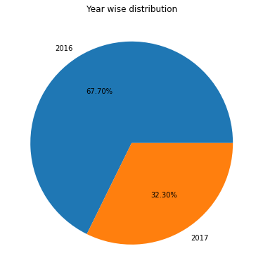

```python
createPieChart(df,'Year','Year wise distribution', 5, 5)
```

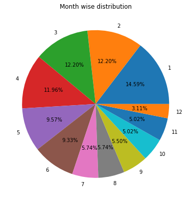

```python
createPieChart(df,'Month','Month wise distribution', 5, 5)
```

- During First half of year(month 1-6) reported more accidents.

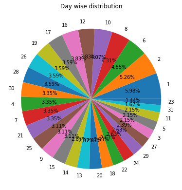

```python
createPieChart(df,'Day','Day wise distribution', 5, 5)
```

```python
# from plotly.subplots import make_subplots
# import plotly.graph_objects as go
# from plotly.offline import plot


# fig = make_subplots(rows=1, cols=2, specs=[[{"type": "pie"}, {"type": "pie"}]])
# #fig.add_trace(createPieChart(df,'Year','Year wise distribution'), domain=dict(x=[0, 0.5]),row=1, col=1)

# fig.add_trace(go.Pie(
#      values=df.Year.unique(),
#      domain=dict(x=[0, 0.5]),
#      name="Year"),
#      row=1, col=1)

# fig.add_trace(go.Pie(
#      values=df.Year.unique(),
#      domain=dict(x=[0.5, 1]),
#      name="Year"),
#      row=1, col=1)

# plot(fig)
```

## Bivariate Analysis

```python
def createCountPlot(df, columns, hue, rows, cols, figWidth, figHeight, hspace):
    fig,axs = plt.subplots(nrows=rows, ncols=cols, figsize=(figWidth, figHeight))
    plt.subplots_adjust(hspace = hspace)
    icol=0
    jrow=0
    for col in columns:
      if rows == 1:
        chart = sns.countplot(x = col, data = df, hue = hue, ax=axs[icol])
      else:
        chart = sns.countplot(x = col, data = df, hue = hue, ax=axs[jrow][icol])

      chart.set_title(col.capitalize() +' count plot by ' + hue, fontsize = 18)
      chart.set_xticklabels(chart.get_xticklabels(), rotation=45)
      chart.set_xlabel(col, fontsize=18)
      chart.set_ylabel("count", fontsize=18)
      chart.tick_params(labelsize=16)
      if icol==2:
        jrow=jrow+1
        icol=0
      else:
        icol = icol+1
```

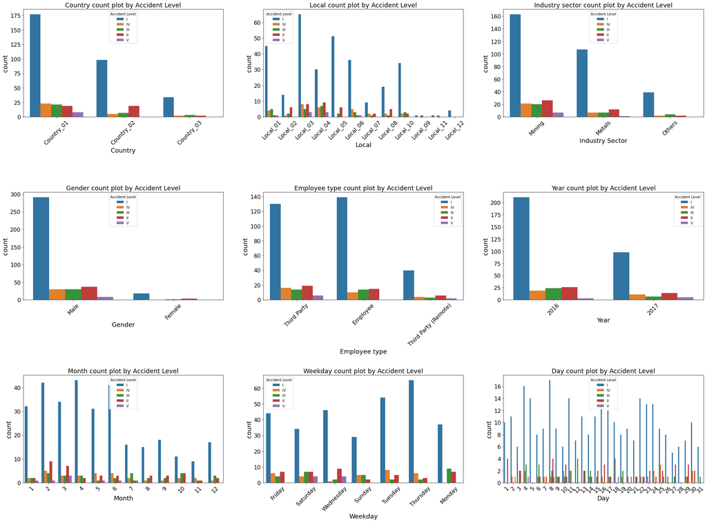

```python
columns = ['Country', 'Local', 'Industry Sector', 'Gender', 'Employee type', 'Year', 'Month', 'Weekday', 'Day']
createCountPlot(df, columns, 'Accident Level', 3, 3, 35, 25, 0.7)
```

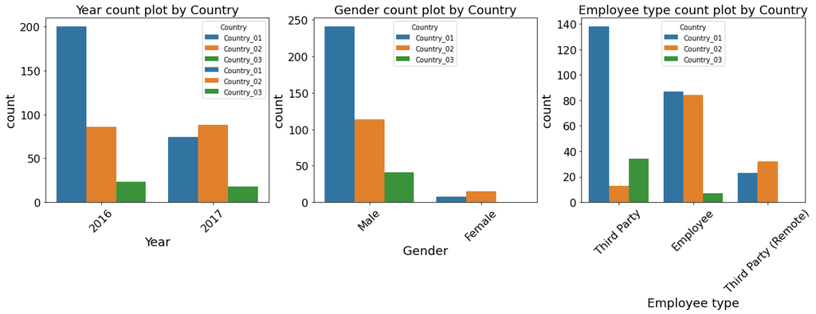

```python
columns = ['Industry Sector', 'Gender', 'Employee type', 'Year']
createCountPlot(df, columns, 'Country', 1, 3, 20, 5, 0.0)
```

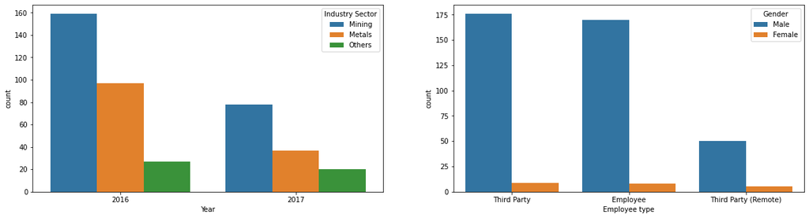

```python
fig,axs = plt.subplots(nrows=1,ncols=2,figsize=(20,5))

sns.countplot(x=df['Year'],hue='Industry Sector',data=df,ax=axs[0])
sns.countplot(x=df['Employee type'],hue='Gender',data=df,ax=axs[1])
```

# NLP Preprocessing

```python
# Text preprocessing and stopwords
from text_preprocess_py import *
```

```python
print('=='*30); print('Converting description to lower case')
df['Cleaned_Description'] = df['Description'].apply(lambda x : x.lower())

print('Replacing apostrophes to the standard lexicons')
df['Cleaned_Description'] = df['Cleaned_Description'].apply(lambda x : replace_words(x))

print('Removing punctuations')
df['Cleaned_Description'] = df['Cleaned_Description'].apply(lambda x: remove_punctuation(x))

print('Applying Lemmatizer')
df['Cleaned_Description'] = df['Cleaned_Description'].apply(lambda x: lemmatize(x))

print('Removing multiple spaces between words')
df['Cleaned_Description'] = df['Cleaned_Description'].apply(lambda x: re.sub(' +', ' ', x))

print('Removing stop words')
df['Cleaned_Description'] = df['Cleaned_Description'].apply(lambda x: remove_stopwords(x))

print('=='*30)
```

```
============================================================
Converting description to lower case
Replacing apostrophes to the standard lexicons
Removing punctuations
Applying Lemmatizer
Removing multiple spaces between words
Removing stop words
============================================================
```

- As different lines are of different length. We are padding the sequences using the max length

```python
# Get length of each line
df['Desc_length'] = df['Cleaned_Description'].str.len()

print('Min Desc length: {}'.format(df['Desc_length'].min()))
print('Max Desc length: {}'.format(df['Desc_length'].max()))
```

```
Min Desc length: 64
Max Desc length: 680
```

```python
# Get number of words for each Desc
df['word_num'] = df['Cleaned_Description'].apply(lambda x: len(x.split(' ')))
print('Min number of words: {}'.format(df['word_num'].min()))
print('Max number of words: {}'.format(df['word_num'].max()))
```

```
Min number of words: 10
Max number of words: 98
```

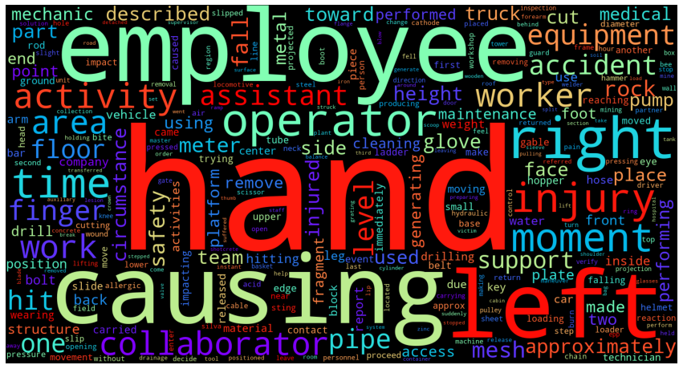

```python
wordcloud = WordCloud(width = 1500, height = 800, random_state=0, background_color='black', colormap='rainbow', \
                      min_font_size=5, max_words=300, collocations=False).generate(" ".join(df['Cleaned_Description'].values))
plt.figure(figsize=(15,10))
plt.imshow(wordcloud)
plt.axis('off')
plt.show()
```

### Observations

We can see lot of words related to body, employee, movement, tools and accident. So these words could be used as keywords for chatbot.

## Feature Engineering

- Variable creation using Glove word embeddings

```python
embeddings_index = {}
EMBEDDING_FILE = '/content/drive/MyDrive/jupyter/capstone/glove.6B.200d.txt'
f = open(EMBEDDING_FILE)
for line in tqdm(f):
    values = line.split()
    word = values[0]
    coefs = np.asarray(values[1:], dtype='float32')
    embeddings_index[word] = coefs
f.close()

print('Found %s word vectors.' % len(embeddings_index))
```

```
400000it [00:22, 17673.26it/s]
```

```
Found 400000 word vectors.
```

```python
def sent2vec(s):
    words = str(s).lower()
    words = word_tokenize(words)
    words = [w for w in words if not w in stop_words]
    words = [w for w in words if w.isalpha()]
    M = []
    for w in words:
        try:
            M.append(embeddings_index[w])
        except:
            continue
    M = np.array(M)
    v = M.sum(axis=0)
    if type(v) != np.ndarray:
        return np.zeros(300)
    return v / np.sqrt((v ** 2).sum())
```

```python
glove_df = pd.DataFrame([sent2vec(x) for x in tqdm(df['Cleaned_Description'])])
```

```python
glove_df = glove_df.add_suffix('_gl')
glove_df.head()
```

|  | 0_gl | 1_gl | 2_gl | 3_gl | 4_gl | 5_gl | 6_gl | 7_gl | 8_gl | 9_gl | 10_gl | 11_gl | 12_gl | 13_gl | 14_gl | 15_gl | 16_gl | 17_gl | 18_gl | 19_gl | 20_gl | 21_gl | 22_gl | 23_gl | 24_gl | 25_gl | 26_gl | 27_gl | 28_gl | … |
| --- | --- | --- | --- | --- | --- | --- | --- | --- | --- | --- | --- | --- | --- | --- | --- | --- | --- | --- | --- | --- | --- | --- | --- | --- | --- | --- | --- | --- | --- | --- |
| 0 | 0.001399 | 0.089986 | 0.001088 | -0.030902 | 0.006192 | 0.068703 | -0.102348 | -0.028767 | -0.062569 | 0.041729 | -0.016129 | 0.013318 | 0.112337 | 0.001674 | 0.087108 | -0.019333 | -0.036656 | -0.028691 | 0.070910 | 0.008074 | -0.043012 | 0.614812 | 0.090625 | 0.001879 | 0.034345 | 0.034816 | -0.030851 | 0.025824 | -0.031809 | … |
| 1 | -0.014662 | 0.049947 | 0.024440 | -0.106530 | 0.004334 | 0.028683 | -0.097660 | -0.064637 | -0.018871 | -0.047895 | 0.040154 | 0.049868 | 0.042412 | 0.023929 | -0.010415 | -0.002720 | -0.033393 | 0.042052 | 0.126448 | -0.090047 | -0.107699 | 0.564138 | -0.058079 | -0.074854 | 0.115027 | -0.104237 | -0.077160 | 0.004913 | 0.001651 | … |
| 2 | -0.008349 | -0.058275 | -0.094715 | -0.074118 | -0.024737 | 0.027817 | -0.083538 | -0.058431 | -0.055072 | -0.028999 | 0.008551 | -0.006957 | -0.000247 | 0.096532 | 0.113783 | 0.001838 | -0.041752 | -0.001091 | 0.008712 | -0.038032 | -0.008735 | 0.582276 | 0.069600 | -0.024584 | 0.052616 | 0.001921 | -0.020729 | -0.004270 | -0.085750 | … |
| 3 | 0.000628 | 0.058891 | -0.061672 | -0.058790 | -0.013520 | 0.062692 | -0.055923 | -0.049526 | -0.003858 | 0.029369 | 0.049371 | 0.025559 | 0.046074 | 0.083793 | 0.077206 | -0.015460 | 0.012461 | 0.035334 | 0.015318 | -0.029121 | 0.010289 | 0.581658 | 0.074880 | -0.070918 | 0.031072 | 0.028037 | 0.002711 | 0.001376 | -0.117610 | … |
| 4 | -0.034495 | 0.023507 | -0.062407 | -0.061290 | -0.002992 | 0.029277 | -0.086362 | -0.085732 | -0.043758 | -0.044062 | 0.043147 | -0.017204 | 0.026751 | 0.062899 | 0.090752 | -0.004989 | -0.061567 | -0.001266 | 0.036589 | -0.085420 | 0.032581 | 0.630705 | 0.021609 | -0.025995 | 0.062090 | 0.018148 | 0.022533 | 0.011514 | -0.066844 | … |

5 rows × 200 columns

- Variable creation using TFIDF Features

```python
tfidf_df = pd.DataFrame()
for i in [1,2,3]:
    vec_tfidf = TfidfVectorizer(max_features=10, norm='l2', stop_words='english', lowercase=True, use_idf=True, ngram_range=(i,i))
    X = vec_tfidf.fit_transform(df['Cleaned_Description']).toarray()
    tfs = pd.DataFrame(X, columns=["TFIDF_" + n for n in vec_tfidf.get_feature_names_out()])
    tfidf_df = pd.concat([tfidf_df.reset_index(drop=True), tfs.reset_index(drop=True)], axis=1)
```

```python
print('TFIDF Shape: ',tfidf_df.shape)
tfidf_df.head(2)
```

```
TFIDF Shape:  (418, 30)
```

|  | TFIDF_activity | TFIDF_area | TFIDF_causing | TFIDF_employee | TFIDF_hand | TFIDF_injury | TFIDF_left | TFIDF_operator | TFIDF_right | TFIDF_time | TFIDF_causing injury | TFIDF_described injury | TFIDF_employee reports | TFIDF_finger left | TFIDF_injury described | TFIDF_left foot | TFIDF_left hand | TFIDF_medical center | TFIDF_right hand | TFIDF_time accident | TFIDF_causing injury described | TFIDF_described time accident | TFIDF_finger left hand | TFIDF_finger right hand | TFIDF_generating described injury | TFIDF_hand causing injury | TFIDF_injury time accident | TFIDF_left hand causing | TFIDF_right hand causing | … |
| --- | --- | --- | --- | --- | --- | --- | --- | --- | --- | --- | --- | --- | --- | --- | --- | --- | --- | --- | --- | --- | --- | --- | --- | --- | --- | --- | --- | --- | --- | --- |
| 0 | 0.0 | 0.0 | 0.0 | 0.0 | 0.0 | 0.0 | 0.0 | 0.0 | 0.0 | 0.0 | 0.0 | 0.0 | 0.0 | 0.0 | 0.0 | 0.0 | 0.0 | 0.0 | 0.0 | 0.0 | 0.0 | 0.0 | 0.0 | 0.0 | 0.0 | 0.0 | 0.0 | 0.0 | 0.0 | … |
| 1 | 0.0 | 1.0 | 0.0 | 0.0 | 0.0 | 0.0 | 0.0 | 0.0 | 0.0 | 0.0 | 0.0 | 0.0 | 0.0 | 0.0 | 0.0 | 0.0 | 0.0 | 0.0 | 0.0 | 0.0 | 0.0 | 0.0 | 0.0 | 0.0 | 0.0 | 0.0 | 0.0 | 0.0 | 0.0 | … |

```python
# To replace white space everywhere in Employee type
df['Employee type'] = df['Employee type'].str.replace(' ', '_')
df['Employee type'].value_counts()
```

```
Third_Party             185
Employee                178
Third_Party_(Remote)     55
Name: Employee type, dtype: int64
```

```python
# To replace white space everywhere in Critical Risk
df['Critical Risk'] = df['Critical Risk'].str.replace('\n', '').str.replace(' ', '_')
df['Critical Risk'].value_counts().head()
```

```
Others                 229
Pressed                 24
Manual_Tools            20
Chemical_substances     17
Cut                     14
Name: Critical Risk, dtype: int64
```

- Variable creation using Label Encoding

```python
# Create Industry DataFrame
feature_df = pd.DataFrame()

# Label encoding
df['Weekday'] = df['Weekday'].replace('Monday', 'aMonday').replace('Tuesday', 'bTuesday').replace('Wednesday', 'cWednesday').replace('Thursday', 'dThursday').replace('Friday', 'eFriday').replace('Saturday', 'fSaturday').replace('Sunday', 'gSunday')
feature_df['Weekday'] = LabelEncoder().fit_transform(df['Weekday']).astype(np.int8)

feature_df['Accident Level'] = LabelEncoder().fit_transform(df['Accident Level']).astype(np.int8)
feature_df['Potential Accident Level'] = LabelEncoder().fit_transform(df['Potential Accident Level']).astype(np.int8)
```

```python
print('Label Encoding Shape: ',feature_df.shape)
feature_df.head(5)
```

```
Label Encoding Shape:  (418, 3)
```

|  | Weekday | Accident Level | Potential Accident Level |
| --- | --- | --- | --- |
| 0 | 4 | 0 | 3 |
| 1 | 5 | 0 | 3 |
| 2 | 2 | 0 | 2 |
| 3 | 4 | 0 | 0 |
| 4 | 6 | 3 | 3 |

- Variable creation using One-Hot Encoding

```python
# convert integers to dummy variables (i.e. one hot encoded)
dummy_target = np_utils.to_categorical(feature_df['Accident Level'])
dummy_target
```

```
array([[1., 0., 0., 0., 0.],
       [1., 0., 0., 0., 0.],
       [1., 0., 0., 0., 0.],
       ...,
       [1., 0., 0., 0., 0.],
       [1., 0., 0., 0., 0.],
       [1., 0., 0., 0., 0.]], dtype=float32)
```

```python
# Dummy variables encoding
Country_encoding = pd.get_dummies(df['Country'], columns=["Country"])
Local_encoding = pd.get_dummies(df['Local'], columns=["Local"])
Gender_encoding = pd.get_dummies(df['Gender'], columns=["Gender"])
Industry_encoding = pd.get_dummies(df['Industry Sector'], columns=['Industry Sector'], prefix='IS')
EmpType_encoding = pd.get_dummies(df['Employee type'], columns=['Employee type'], prefix='EmpType')
CR_encoding = pd.get_dummies(df['Critical Risk'], columns=['Critical Risk'], prefix='CR')

# Merge the above dataframe with the original dataframe feature_df
feature_df = feature_df.join(Country_encoding.reset_index(drop=True)).join(Local_encoding.reset_index(drop=True)).join(Gender_encoding.reset_index(drop=True)).join(Industry_encoding.reset_index(drop=True)).join(EmpType_encoding.reset_index(drop=True)).join(CR_encoding.reset_index(drop=True))

feature_df = df[['Year','Month','Day','WeekofYear']].reset_index(drop=True).join(feature_df.reset_index(drop=True))
```

```python
print('Final Shape after applying feature engineering: ',feature_df.shape)
feature_df.head(3)
```

```
Final Shape after applying feature engineering:  (418, 63)
```

|  | Year | Month | Day | WeekofYear | Weekday | Accident Level | Potential Accident Level | Country_01 | Country_02 | Country_03 | Local_01 | Local_02 | Local_03 | Local_04 | Local_05 | Local_06 | Local_07 | Local_08 | Local_09 | Local_10 | Local_11 | Local_12 | Female | Male | IS_Metals | IS_Mining | IS_Others | EmpType_Employee | EmpType_Third_Party | … |
| --- | --- | --- | --- | --- | --- | --- | --- | --- | --- | --- | --- | --- | --- | --- | --- | --- | --- | --- | --- | --- | --- | --- | --- | --- | --- | --- | --- | --- | --- | --- |
| 0 | 2016 | 1 | 1 | 53 | 4 | 0 | 3 | 1 | 0 | 0 | 1 | 0 | 0 | 0 | 0 | 0 | 0 | 0 | 0 | 0 | 0 | 0 | 0 | 1 | 0 | 1 | 0 | 0 | 1 | … |
| 1 | 2016 | 1 | 2 | 53 | 5 | 0 | 3 | 0 | 1 | 0 | 0 | 1 | 0 | 0 | 0 | 0 | 0 | 0 | 0 | 0 | 0 | 0 | 0 | 1 | 0 | 1 | 0 | 1 | 0 | … |
| 2 | 2016 | 1 | 6 | 1 | 2 | 0 | 2 | 1 | 0 | 0 | 0 | 0 | 1 | 0 | 0 | 0 | 0 | 0 | 0 | 0 | 0 | 0 | 0 | 1 | 0 | 1 | 0 | 0 | 0 | … |

```python
# Check NaN values
np.any(np.isnan(feature_df))
```

```
False
```

```python
# Consider only top 20 GLOVE features & Combining TFIDF and Encoded Feature
f_df = feature_df.join(pd.DataFrame(glove_df).iloc[:,0:20].reset_index(drop=True))
f_df = f_df.join(tfidf_df.reset_index(drop=True))
```

```python
f_df.head()
```

|  | Year | Month | Day | WeekofYear | Weekday | Accident Level | Potential Accident Level | Country_01 | Country_02 | Country_03 | Local_01 | Local_02 | Local_03 | Local_04 | Local_05 | Local_06 | Local_07 | Local_08 | Local_09 | Local_10 | Local_11 | Local_12 | Female | Male | IS_Metals | IS_Mining | IS_Others | EmpType_Employee | EmpType_Third_Party | … |
| --- | --- | --- | --- | --- | --- | --- | --- | --- | --- | --- | --- | --- | --- | --- | --- | --- | --- | --- | --- | --- | --- | --- | --- | --- | --- | --- | --- | --- | --- | --- |
| 0 | 2016 | 1 | 1 | 53 | 4 | 0 | 3 | 1 | 0 | 0 | 1 | 0 | 0 | 0 | 0 | 0 | 0 | 0 | 0 | 0 | 0 | 0 | 0 | 1 | 0 | 1 | 0 | 0 | 1 | … |
| 1 | 2016 | 1 | 2 | 53 | 5 | 0 | 3 | 0 | 1 | 0 | 0 | 1 | 0 | 0 | 0 | 0 | 0 | 0 | 0 | 0 | 0 | 0 | 0 | 1 | 0 | 1 | 0 | 1 | 0 | … |
| 2 | 2016 | 1 | 6 | 1 | 2 | 0 | 2 | 1 | 0 | 0 | 0 | 0 | 1 | 0 | 0 | 0 | 0 | 0 | 0 | 0 | 0 | 0 | 0 | 1 | 0 | 1 | 0 | 0 | 0 | … |
| 3 | 2016 | 1 | 8 | 1 | 4 | 0 | 0 | 1 | 0 | 0 | 0 | 0 | 0 | 1 | 0 | 0 | 0 | 0 | 0 | 0 | 0 | 0 | 0 | 1 | 0 | 1 | 0 | 0 | 1 | … |
| 4 | 2016 | 1 | 10 | 1 | 6 | 3 | 3 | 1 | 0 | 0 | 0 | 0 | 0 | 1 | 0 | 0 | 0 | 0 | 0 | 0 | 0 | 0 | 0 | 1 | 0 | 1 | 0 | 0 | 1 | … |

5 rows × 113 columns

```python
f_df.info
```

```
<bound method DataFrame.info of      Year  Month  ...  TFIDF_right hand causing  TFIDF_time accident employee
0    2016      1  ...                       0.0                           0.0
1    2016      1  ...                       0.0                           0.0
2    2016      1  ...                       0.0                           0.0
3    2016      1  ...                       0.0                           0.0
4    2016      1  ...                       0.0                           0.0
..    ...    ...  ...                       ...                           ...
413  2017      7  ...                       0.0                           0.0
414  2017      7  ...                       0.0                           0.0
415  2017      7  ...                       0.0                           0.0
416  2017      7  ...                       0.0                           0.0
417  2017      7  ...                       0.0                           0.0

[418 rows x 113 columns]>
```

## Designing Train, Test Data and Model

```python
# Create Training and Test Set
X = f_df.drop(['Accident Level','Potential Accident Level'], axis = 1) # Considering all Predictors
y = f_df['Accident Level']
```

- Creating Train and Test dataset using Label encoding target variable

```python
X_train, X_test, y_train, y_test = train_test_split(X, y, test_size = 0.20, random_state = 1, stratify = y)
```

- Creating Train and Test dataset using One-Hot encoding target variable

```python
X_train, X_test, y_train_dummy_target, y_test_dummy_target = train_test_split(X, dummy_target, test_size = 0.20,
                                                                              random_state = 1, stratify = y)
```

```python
print('X_train shape : ({0},{1})'.format(X_train.shape[0], X_train.shape[1]))
print('y_train shape : ({0},)'.format(y_train.shape[0]))
print('X_test shape : ({0},{1})'.format(X_test.shape[0], X_test.shape[1]))
print('y_test shape : ({0},)'.format(y_test.shape[0]))

print('y_train_dummy_target : ({0},)'.format(y_train_dummy_target.shape[0]))
print('y_test_dummy_target shape : ({0},)'.format(y_test_dummy_target.shape[0]))
```

```
X_train shape : (334,111)
y_train shape : (334,)
X_test shape : (84,111)
y_test shape : (84,)
y_train_dummy_target : (334,)
y_test_dummy_target shape : (84,)
```

```python
y_train.value_counts()
```

```
0    247
1     32
2     25
3     24
4      6
Name: Accident Level, dtype: int64
```

Applying upsampling technique: SMOTE

```python
sm = SMOTE(random_state=1)
X_train_smote, y_train_smote = sm.fit_resample(X_train, y_train)
df_smote = pd.concat([pd.DataFrame(X_train_smote), pd.DataFrame(y_train_smote)], axis=1)
# df_smote.columns = [f_df.drop(['Accident Level'], axis = 1).columns]
```

```python
# Separate input features and target
X_train_smote = pd.DataFrame(df_smote.drop(['Accident Level'], axis=1)) # Considering all Predictors
y_train_smote = pd.DataFrame(df_smote['Accident Level'])
```

```python
# Display new accident level counts
y_train_smote['Accident Level'].value_counts()
```

```
4    247
3    247
2    247
1    247
0    247
Name: Accident Level, dtype: int64
```

```python
# convert integers to dummy variables (i.e. one hot encoded)
y_train_smote_dummy = np_utils.to_categorical(y_train_smote['Accident Level'])
y_train_smote_dummy
```

```
array([[0., 1., 0., 0., 0.],
       [0., 1., 0., 0., 0.],
       [1., 0., 0., 0., 0.],
       ...,
       [0., 0., 0., 0., 1.],
       [0., 0., 0., 0., 1.],
       [0., 0., 0., 0., 1.]], dtype=float32)
```

- Varible Tansformation (Normalization and Scaling)

```python
# Transform independent features
scaler_X = StandardScaler()#StandardScaler()
pipeline = Pipeline(steps=[('s', scaler_X)])
X_train.iloc[:,:6] = pipeline.fit_transform(X_train.iloc[:,:6]) # Scaling only first 6 feautres

X_test.iloc[:,:6] = pipeline.fit_transform(X_test.iloc[:,:6]) # Scaling only first 6 feautres
```

```python
X_train.head(3)
```

|  | Year | Month | Day | WeekofYear | Weekday | Country_01 | Country_02 | Country_03 | Local_01 | Local_02 | Local_03 | Local_04 | Local_05 | Local_06 | Local_07 | Local_08 | Local_09 | Local_10 | Local_11 | Local_12 | Female | Male | IS_Metals | IS_Mining | IS_Others | EmpType_Employee | EmpType_Third_Party | EmpType_Third_Party_(Remote) | CR_Bees | … |
| --- | --- | --- | --- | --- | --- | --- | --- | --- | --- | --- | --- | --- | --- | --- | --- | --- | --- | --- | --- | --- | --- | --- | --- | --- | --- | --- | --- | --- | --- | --- |
| 202 | -0.700765 | 1.168926 | -1.673853 | 0.996914 | 0.075496 | -1.237054 | 1 | 0 | 0 | 0 | 0 | 0 | 1 | 0 | 0 | 0 | 0 | 0 | 0 | 0 | 0 | 1 | 1 | 0 | 0 | 0 | 0 | 1 | 0 | … |
| 258 | -0.700765 | 1.802213 | 1.559083 | 1.934247 | -0.997510 | -1.237054 | 1 | 0 | 0 | 0 | 0 | 0 | 0 | 0 | 0 | 1 | 0 | 0 | 0 | 0 | 0 | 1 | 1 | 0 | 0 | 1 | 0 | 0 | 0 | … |
| 6 | -0.700765 | -1.364221 | 0.058077 | -1.382469 | 1.148501 | -1.237054 | 1 | 0 | 0 | 0 | 0 | 0 | 1 | 0 | 0 | 0 | 0 | 0 | 0 | 0 | 0 | 1 | 1 | 0 | 0 | 1 | 0 | 0 | 0 | … |

3 rows × 111 columns

- Applying PCA

```python
cov = np.cov(X_train.T) # the relevanat covariance matrix
#generating the eigen values and the eigen vectors
e_vals, e_vecs = np.linalg.eig(cov)
tot = sum(e_vals)
var_exp = [( i /tot ) * 100 for i in sorted(e_vals, reverse=True)]
cum_var_exp = np.cumsum(var_exp)
# print("Cumulative Variance Explained", cum_var_exp)
```

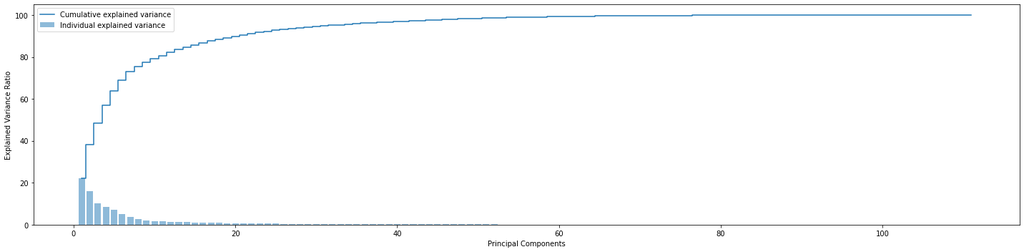

```python
# Plotting the variance expalained by the principal components and the cumulative variance explained.
plt.figure(figsize=(20 , 5))
plt.bar(range(1, e_vals.size + 1), var_exp, alpha = 0.5, align = 'center', label = 'Individual explained variance')
plt.step(range(1, e_vals.size + 1), cum_var_exp, where='mid', label = 'Cumulative explained variance')
plt.ylabel('Explained Variance Ratio')
plt.xlabel('Principal Components')
plt.legend(loc = 'best')
plt.tight_layout()
plt.show()
```

```python
pca = PCA(n_components = 0.90)
X_train_reduced = pca.fit_transform(X_train)
X_test_reduced = pca.transform(X_test)
```

```python
print(X_train.shape)
print(X_train_smote.shape)
print(X_train_reduced.shape)
```

```
(334, 111)
(1235, 111)
(334, 21)
```

- Design, train and test machine learning classifiers

```python
def multiclass_logloss(actual, predicted, eps=1e-15):
    """Multi class version of Logarithmic Loss metric.
    :param actual: Array containing the actual target classes
    :param predicted: Matrix with class predictions, one probability per class
    """
    # Convert 'actual' to a binary array if it's not already:
    if len(actual.shape) == 1:
        actual2 = np.zeros((actual.shape[0], predicted.shape[1]))
        for i, val in enumerate(actual):
            actual2[i, val] = 1
        actual = actual2

    clip = np.clip(predicted, eps, 1 - eps)
    rows = actual.shape[0]
    vsota = np.sum(actual * np.log(clip))
    return -1.0 / rows * vsota
```

```python
def train_test_model(model, method, X_train, X_test, y_train, y_test, of_type, index, scale, report, save_model):

    if report == "yes":
        print (model)
        print ("***************************************************************************")

    if method == 'LGBMClassifier':

      model.fit(X_train, y_train) # Fit the model on Training set
    else:
      model.fit(X_train, y_train) # Fit the model on Training set

    from sklearn.metrics import accuracy_score, f1_score, confusion_matrix, recall_score, precision_score

    if of_type == "coef":
        # Intercept and Coefficients
        print("The intercept for our model is {}".format(model.intercept_), "\n")

        for idx, col_name in enumerate(X_train.columns):
            print("The coefficient for {} is {}".format(col_name, model.coef_.ravel()[idx]))

    y_pred = model.predict(X_test) # Predict on Test set

    # Initialise mc_logloss
    mc_logloss = 1.00
    if method != 'RidgeClassifier':
      y_predictions = model.predict_proba(X_test)

    train_accuracy_score = model.score(X_train, y_train)
    test_accuracy_score = model.score(X_test, y_test)

    precision_score = precision_score(y_test, y_pred, average='weighted')
    recall_score = recall_score(y_test, y_pred, average='weighted')
    f1_score = f1_score(y_test, y_pred, average='weighted')

    if method != 'RidgeClassifier':
      mc_logloss = multiclass_logloss(y_test, y_predictions, eps=1e-15)

    if report == "yes":
      # Model - Confusion matrix
      model_cm = confusion_matrix(y_test, y_pred)

      sns.heatmap(model_cm, annot=True,  fmt='.2f', xticklabels = ["I", "II", "III", "IV", "V"] , yticklabels = ["I", "II", "III", "IV", "V"] )
      plt.ylabel('Actual')
      plt.xlabel('Predicted')
      plt.show()

      # Model - Classification report
      model_cr = classification_report(y_test, y_pred)
      print(model_cr)

    # Store the accuracy results for each model in a dataframe for final comparison
    resultsDf = pd.DataFrame({'Method': method, 'Train Accuracy': train_accuracy_score, 'Test Accuracy': test_accuracy_score,
                              'Precision': precision_score, 'Recall': recall_score, 'F1-Score': f1_score,
                              'Multi-Class Logloss': mc_logloss}, index=[index])

    # Save the model
    if save_model == "yes":
      filename = 'finalised_model.sav'
      pickle.dump(model, open(filename, 'wb'))

    return resultsDf  # return all the metrics along with predictions
```

```python
import lightgbm as lgb

def train_test_allmodels(X_train_common, X_test_common, y_train, y_test, scale):

    # define classification models
    models=[['LogisticRegression',LogisticRegression(solver='lbfgs', multi_class='multinomial', random_state = 1)],
        ['RidgeClassifier',RidgeClassifier(random_state = 1)],
        #['Lasso',Lasso(random_state = 1)],
        ['KNeighborsClassifier',KNeighborsClassifier(n_neighbors = 3)],
        ['SVC',SVC(kernel = 'rbf', probability=True)],
        ['DecisionTreeClassifier',DecisionTreeClassifier(criterion = 'gini', random_state=1)],
        ['RandomForestClassifier',RandomForestClassifier(n_estimators=10, random_state=1)],
        ['BaggingClassifier',BaggingClassifier(n_estimators=30, max_samples=0.75, random_state=1, oob_score=True)],
        ['ExtraTreesClassifier',ExtraTreesClassifier(n_estimators = 50, criterion='entropy', max_features='auto', min_samples_split=2,
                                 bootstrap=True, oob_score=True)],
        ['AdaBoostClassifier',AdaBoostClassifier(n_estimators=100, learning_rate=0.25, random_state=1)],
        ['GradientBoostingClassifier',GradientBoostingClassifier(loss='deviance', n_estimators=50, learning_rate=0.1, validation_fraction=0.2,
                                       random_state=1)],
        ['LGBMClassifier',LGBMClassifier(random_state=1, metric = "multi_logloss", objective="multiclass")],
                                         #early_stopping_rounds = 30)],
        ['XGBClassifier',XGBClassifier(min_child_weight = 7, max_depth = 6, objective="multi:softmax", learning_rate = 0.1, gamma = 0.4,
                                       colsample_bytree = 0.5)]
    ]

    resultsDf_common = pd.DataFrame()
    i = 1
    for name, classifier in models:
        # Train and Test the model
        reg_resultsDf = train_test_model(classifier, name, X_train_common, X_test_common, y_train, y_test, 'none', i, scale, 'no', 'no')

        # Store the accuracy results for each model in a dataframe for final comparison
        resultsDf_common = pd.concat([resultsDf_common, reg_resultsDf])
        i = i+1

    return resultsDf_common
```

- Running all models with Original data

```python
# Train and Test all models with Lasso interaction terms
train_test_allmodels(X_train, X_test, y_train, y_test, 'no')
```

|  | Method | Train Accuracy | Test Accuracy | Precision | Recall | F1-Score | Multi-Class Logloss |
| --- | --- | --- | --- | --- | --- | --- | --- |
| 1 | LogisticRegression | 0.760479 | 0.714286 | 0.553571 | 0.714286 | 0.623742 | 0.895054 |
| 2 | RidgeClassifier | 0.760479 | 0.726190 | 0.555850 | 0.726190 | 0.629704 | 1.000000 |
| 3 | KNeighborsClassifier | 0.766467 | 0.702381 | 0.551236 | 0.702381 | 0.617697 | 6.886016 |
| 4 | SVC | 0.739521 | 0.738095 | 0.544785 | 0.738095 | 0.626875 | 0.891100 |
| 5 | DecisionTreeClassifier | 0.997006 | 0.595238 | 0.595238 | 0.595238 | 0.594998 | 13.979981 |
| 6 | RandomForestClassifier | 0.961078 | 0.726190 | 0.542456 | 0.726190 | 0.621018 | 3.470738 |
| 7 | BaggingClassifier | 0.964072 | 0.726190 | 0.549071 | 0.726190 | 0.625331 | 1.307009 |
| 8 | ExtraTreesClassifier | 0.997006 | 0.738095 | 0.551348 | 0.738095 | 0.631199 | 1.244055 |
| 9 | AdaBoostClassifier | 0.745509 | 0.714286 | 0.540070 | 0.714286 | 0.615079 | 1.264493 |
| 10 | GradientBoostingClassifier | 0.985030 | 0.726190 | 0.603480 | 0.726190 | 0.650510 | 0.929764 |
| 11 | LGBMClassifier | 0.997006 | 0.690476 | 0.563283 | 0.690476 | 0.620428 | 1.359473 |
| 12 | XGBClassifier | 0.973054 | 0.726190 | 0.555850 | 0.726190 | 0.629704 | 0.940114 |

- Running all models with Smote data

```python
train_test_allmodels(X_train_smote, X_test, y_train_smote, y_test, 'no')
```

|  | Method | Train Accuracy | Test Accuracy | Precision | Recall | F1-Score | Multi-Class Logloss |
| --- | --- | --- | --- | --- | --- | --- | --- |
| 1 | LogisticRegression | 0.432389 | 0.309524 | 0.616790 | 0.309524 | 0.397904 | 1.527526 |
| 2 | RidgeClassifier | 0.866397 | 0.071429 | 0.005102 | 0.071429 | 0.009524 | 1.000000 |
| 3 | KNeighborsClassifier | 0.908502 | 0.142857 | 0.474589 | 0.142857 | 0.150594 | 9.354805 |
| 4 | SVC | 0.295547 | 0.071429 | 0.005102 | 0.071429 | 0.009524 | 1.543894 |
| 5 | DecisionTreeClassifier | 0.999190 | 0.500000 | 0.578755 | 0.500000 | 0.533924 | 17.269388 |
| 6 | RandomForestClassifier | 0.998381 | 0.607143 | 0.592472 | 0.607143 | 0.598975 | 1.836841 |
| 7 | BaggingClassifier | 0.998381 | 0.595238 | 0.595448 | 0.595238 | 0.594215 | 2.290931 |
| 8 | ExtraTreesClassifier | 0.999190 | 0.678571 | 0.568533 | 0.678571 | 0.618697 | 1.035968 |
| 9 | AdaBoostClassifier | 0.636437 | 0.642857 | 0.621212 | 0.642857 | 0.629181 | 1.333566 |
| 10 | GradientBoostingClassifier | 0.995142 | 0.666667 | 0.594830 | 0.666667 | 0.628178 | 1.118899 |
| 11 | LGBMClassifier | 0.999190 | 0.714286 | 0.560579 | 0.714286 | 0.628166 | 1.478114 |
| 12 | XGBClassifier | 0.999190 | 0.714286 | 0.625850 | 0.714286 | 0.666486 | 1.065537 |

- Running all models with Reduced (PCA) data

```python
train_test_allmodels(X_train_reduced, X_test_reduced, y_train, y_test, 'no')
```

|  | Method | Train Accuracy | Test Accuracy | Precision | Recall | F1-Score | Multi-Class Logloss |
| --- | --- | --- | --- | --- | --- | --- | --- |
| 1 | LogisticRegression | 0.736527 | 0.738095 | 0.551348 | 0.738095 | 0.631199 | 0.868395 |
| 2 | RidgeClassifier | 0.739521 | 0.738095 | 0.551348 | 0.738095 | 0.631199 | 1.000000 |
| 3 | KNeighborsClassifier | 0.754491 | 0.702381 | 0.558303 | 0.702381 | 0.622109 | 6.882591 |
| 4 | SVC | 0.739521 | 0.738095 | 0.544785 | 0.738095 | 0.626875 | 0.907685 |
| 5 | DecisionTreeClassifier | 0.997006 | 0.583333 | 0.640564 | 0.583333 | 0.606853 | 14.391157 |
| 6 | RandomForestClassifier | 0.973054 | 0.738095 | 0.551348 | 0.738095 | 0.631199 | 3.892421 |
| 7 | BaggingClassifier | 0.967066 | 0.738095 | 0.551348 | 0.738095 | 0.631199 | 1.702225 |
| 8 | ExtraTreesClassifier | 0.994012 | 0.738095 | 0.551348 | 0.738095 | 0.631199 | 1.296270 |
| 9 | AdaBoostClassifier | 0.766467 | 0.738095 | 0.551348 | 0.738095 | 0.631199 | 1.234522 |
| 10 | GradientBoostingClassifier | 0.979042 | 0.714286 | 0.553571 | 0.714286 | 0.623742 | 1.106259 |
| 11 | LGBMClassifier | 0.997006 | 0.702381 | 0.551236 | 0.702381 | 0.617697 | 1.188462 |
| 12 | XGBClassifier | 0.967066 | 0.702381 | 0.544345 | 0.702381 | 0.613347 | 0.918235 |

- Applying Hyperparameter Tuning

```python
def hyperparameterstune_model(name, model, X_train, y_train, param_grid):

    start = time.time()  # note the start time

    # Before starting with grid search we need to create a scoring function. This is accomplished using the make_scorer function of scikit-learn.
    mll_scorer = metrics.make_scorer(multiclass_logloss, greater_is_better=False, needs_proba=True)

    # define grid search
    cv = RepeatedStratifiedKFold(n_splits=6, n_repeats=3, random_state=1)
    if name == 'LGBMClassifier':
      grid_search = RandomizedSearchCV(estimator=model, param_distributions=param_grid, n_iter=100, n_jobs=-1, cv=cv,
                                       scoring = mll_scorer, error_score=0)
    else:
      grid_search = GridSearchCV(estimator=model, param_grid=param_grid, n_jobs=-1, cv=cv,
                                 scoring = mll_scorer, error_score=0)

    model_grid_result = grid_search.fit(X_train, y_train)

    # summarize results
    print(name)
    print("Best F1_Score: %f using %s" % (model_grid_result.best_score_, model_grid_result.best_params_))
    means = model_grid_result.cv_results_['mean_test_score']
    stds = model_grid_result.cv_results_['std_test_score']
    params = model_grid_result.cv_results_['params']
    for mean, stdev, param in zip(means, stds, params):
      if param == model_grid_result.best_params_:
        print("%f (%f) with: %r" % (mean, stdev, param))
        print("95% Confidence interval range: ({0:.4f} %, {1:.4f} %)".format(mean-(2*stdev), mean+(2*stdev)))

    end = time.time()  # note the end time
    duration = end - start  # calculate the total duration
    print("Total duration" , duration, "\n")

    return model_grid_result.best_estimator_
```

- Hyperparameter tuning

```python
models=[['LogisticRegression',LogisticRegression()],
    ['Ridge',RidgeClassifier()],
    ['KNeighborsClassifier',KNeighborsClassifier()],
    ['SVC',SVC()],
    ['RandomForestClassifier',RandomForestClassifier()],
    ['BaggingClassifier',BaggingClassifier()],
    ['ExtraTreesClassifier',ExtraTreesClassifier()],
    ['AdaBoostClassifier',AdaBoostClassifier()],
    ['GradientBoostingClassifier',GradientBoostingClassifier()],
    ['LGBMClassifier',LGBMClassifier(verbose=False)],
    ['XGBClassifier',XGBClassifier()]
]

# define model parameters

lr_param_grid = {'solver': ['newton-cg', 'lbfgs', 'liblinear', 'sag', 'saga'],
                 'penalty': ['l2'],
                 #'penalty': ['none', 'l1', 'l2', 'elasticnet'],
                 'C': [100, 10, 1.0, 0.1, 0.01]}
                 #'class_weight':['none','balanced'],
                 #'multi_class':['ovr', 'multinomial']}
ridge_param_grid = {'alpha': [0.1, 0.2, 0.3, 0.4, 0.5, 0.6, 0.7, 0.8, 0.9, 1.0],
                    'class_weight':['none','balanced'],
                    'solver': ['svd', 'cholesky', 'lsqr', 'sparse_cg', 'sag', 'saga']}
#lasso_param_grid = {'alpha': [0.02, 0.024, 0.025, 0.026, 0.03]}
knn_param_grid = {'n_neighbors': range(3, 21, 2),
                 'weights': ['uniform', 'distance'],
                 'metric': ['euclidean', 'manhattan', 'minkowski']}
svc_param_grid = {'kernel': ['poly', 'rbf', 'sigmoid'],
                 'C': [50, 10, 1.0, 0.1, 0.01],
                 'gamma': ['scale'],
                 'decision_function_shape': ['ovo', 'ovr']}
rf_param_grid = {'n_estimators': [10, 100, 1000],
                 'max_features': ['auto', 'sqrt', 'log2']}
                 #'class_weight':['balanced','balanced_subsample','none']}
bag_param_grid = {'n_estimators': [10, 100, 1000],
                 'max_samples': np.arange(0.7, 0.8, 0.05)}
et_param_grid = {'n_estimators': np.arange(10,100,10),
                 'max_features': ['auto', 'sqrt', 'log2'],
                 'min_samples_split': np.arange(2,15,1)}
                 #'class_weight':['balanced','balanced_subsample','none']}
adb_param_grid = {'n_estimators': np.arange(30,100,10),
                 'learning_rate': np.arange(0.1,1,0.5)}
gb_param_grid = {'n_estimators': [10, 50, 100, 500],
                 'learning_rate': [0.0001, 0.001, 0.01, 0.1, 1.0],
                 'subsample':[0.5, 0.7, 1.0],
                 'max_depth': [3, 7, 9]}
lightgbm_param_grid = {'learning_rate': [0.0001, 0.001, 0.01, 0.1, 1.0],
                  'n_estimators': [10, 50, 100, 500, 1000, 5000],
                  'min_child_samples': sp_randint(100, 500),
                  'min_child_weight': [1e-5, 1e-3, 1e-2, 1e-1, 1, 1e1, 1e2, 1e3, 1e4],
                  'boosting_type':['gbdt', 'dart', 'goss'],
                  'bagging_fraction': (0.5, 1),
                  'bagging_frequency' : (5, 8),
                  'feature_fraction': (0.5, 0.8),
                  'max_depth': (10, 13),
                  'min_data_in_leaf': (90, 120),
                  'num_leaves':(1200, 1550),
                  'metric': ['multi_logloss'],
                  'objective': ['multiclass'],
                  'num_class': [5],
                  'early_stopping_rounds':[50],
                  'verbosity':[1]}
xgb_param_grid = {'learning_rate': [0.05, 0.10, 0.15, 0.20, 0.25, 0.30 ],
                  'max_depth' : [3, 4, 5, 6, 8, 10, 12, 15],
                  'min_child_weight': [ 1, 3, 5, 7],
                  'gamma': [0.0, 0.1, 0.2 , 0.3, 0.4],
                  'colsample_bytree': [ 0.3, 0.4, 0.5 , 0.7],
                  'objective': ['multi:softmax'],
                  'eval_metric': ['mlogloss'],
                  'num_class': [5]}

for name, classifier in models:
    if name == 'LogisticRegression':
        lr_best_estimator = hyperparameterstune_model(name, classifier, X_train, y_train, lr_param_grid)
    # elif name == 'Ridge':
    #     ridge_best_estimator = hyperparameterstune_model(name, classifier, X_train, y_train, ridge_param_grid)
    elif name == 'KNeighborsClassifier':
        knn_best_estimator = hyperparameterstune_model(name, classifier, X_train, y_train, knn_param_grid)
    elif name == 'SVC':
        svc_best_estimator = hyperparameterstune_model(name, classifier, X_train, y_train, svc_param_grid)
    elif name == 'RandomForestClassifier':
        rf_best_estimator = hyperparameterstune_model(name, classifier, X_train, y_train, rf_param_grid)
    # elif name == 'BaggingClassifier':
    #     bag_best_estimator = hyperparameterstune_model(name, classifier, X_train, y_train, bag_param_grid)
    # elif name == 'ExtraTreesClassifier':
    #     et_best_estimator = hyperparameterstune_model(name, classifier, X_train, y_train, et_param_grid)
    elif name == 'AdaBoostClassifier':
        adb_best_estimator = hyperparameterstune_model(name, classifier, X_train, y_train, adb_param_grid)
    # elif name == 'GradientBoostingClassifier':
    #     gb_best_estimator = hyperparameterstune_model(name, classifier, X_train, y_train, gb_param_grid)
    # elif name == 'LGBMClassifier':
    #     lightgbm_best_estimator = hyperparameterstune_model(name, classifier, X_train, y_train, lightgbm_param_grid)
    # elif name == 'XGBClassifier':
    #     xgb_best_estimator = hyperparameterstune_model(name, classifier, X_train, y_train, xgb_param_grid)
```

```
LogisticRegression
Best F1_Score: -0.903326 using {'C': 0.01, 'penalty': 'l2', 'solver': 'sag'}
-0.903326 (0.021604) with: {'C': 0.01, 'penalty': 'l2', 'solver': 'sag'}
95% Confidence interval range: (-0.9465 %, -0.8601 %)
Total duration 27.60842490196228

KNeighborsClassifier
Best F1_Score: -2.108952 using {'metric': 'manhattan', 'n_neighbors': 19, 'weights': 'uniform'}
-2.108952 (0.471692) with: {'metric': 'manhattan', 'n_neighbors': 19, 'weights': 'uniform'}
95% Confidence interval range: (-3.0523 %, -1.1656 %)
Total duration 9.337451219558716

SVC
Best F1_Score: 0.000000 using {'C': 50, 'decision_function_shape': 'ovo', 'gamma': 'scale', 'kernel': 'poly'}
0.000000 (0.000000) with: {'C': 50, 'decision_function_shape': 'ovo', 'gamma': 'scale', 'kernel': 'poly'}
95% Confidence interval range: (0.0000 %, 0.0000 %)
Total duration 9.551324129104614

RandomForestClassifier
Best F1_Score: -0.907130 using {'max_features': 'sqrt', 'n_estimators': 1000}
-0.907130 (0.028711) with: {'max_features': 'sqrt', 'n_estimators': 1000}
95% Confidence interval range: (-0.9646 %, -0.8497 %)
Total duration 107.72494983673096

AdaBoostClassifier
Best F1_Score: -1.144518 using {'learning_rate': 0.1, 'n_estimators': 30}
-1.144518 (0.054813) with: {'learning_rate': 0.1, 'n_estimators': 30}
95% Confidence interval range: (-1.2541 %, -1.0349 %)
Total duration 34.900516986846924
```

- Applying Bootstrap Sampling

```python
bf_df = f_df.drop(['Accident Level'], axis = 1)
bf_df = bf_df.join(y.reset_index(drop=True))
bf_df.head(2)
```

|  | Year | Month | Day | WeekofYear | Weekday | Potential Accident Level | Country_01 | Country_02 | Country_03 | Local_01 | Local_02 | Local_03 | Local_04 | Local_05 | Local_06 | Local_07 | Local_08 | Local_09 | Local_10 | Local_11 | Local_12 | Female | Male | IS_Metals | IS_Mining | IS_Others | EmpType_Employee | EmpType_Third_Party | EmpType_Third_Party_(Remote) | … |
| --- | --- | --- | --- | --- | --- | --- | --- | --- | --- | --- | --- | --- | --- | --- | --- | --- | --- | --- | --- | --- | --- | --- | --- | --- | --- | --- | --- | --- | --- | --- |
| 0 | 2016 | 1 | 1 | 53 | 4 | 3 | 1 | 0 | 0 | 1 | 0 | 0 | 0 | 0 | 0 | 0 | 0 | 0 | 0 | 0 | 0 | 0 | 1 | 0 | 1 | 0 | 0 | 1 | 0 | … |
| 1 | 2016 | 1 | 2 | 53 | 5 | 3 | 0 | 1 | 0 | 0 | 1 | 0 | 0 | 0 | 0 | 0 | 0 | 0 | 0 | 0 | 0 | 0 | 1 | 0 | 1 | 0 | 1 | 0 | 0 | … |

2 rows × 113 columns

```python
from sklearn.utils import resample

def bootstrap(name, model, data, n_iterations):

  values = data.values

  # Number of bootstrap samples to create
  n_iterations = n_iterations
  # size of a bootstrap sample
  n_size = int(len(data) * 1)

  # run bootstrap
  # empty list that will hold the scores for each bootstrap iteration
  rf_stats = list()
  for i in range(n_iterations):
      # prepare train and test sets
      train = resample(values, n_samples=n_size)  # Sampling with replacement
      test = np.array([x for x in values if x.tolist() not in train.tolist()])  # picking rest of the data not considered in sample

      # fit model
      rfTree = RandomForestClassifier(n_estimators=50)

      # fit against independent variables and corresponding target values
      rfTree.fit(train[:,:-1], train[:,-1])

      # Take the target column for all rows in test set
      y_bs_test = test[:,-1]

      # evaluate model
      # predict based on independent variables in the test data
      score = rfTree.score(test[:, :-1] , y_bs_test)
      predictions = rfTree.predict(test[:, :-1])

      rf_stats.append(score)

  # plot scores
  print(name)
  plt.hist(rf_stats)
  plt.show()

  # confidence intervals
  alpha = 0.95                             # for 95% confidence
  p = ((1.0-alpha)/2.0) * 100              # tail regions on right and left .25 on each side indicated by P value (border)
  lower = max(0.0, np.percentile(rf_stats, p))
  p = (alpha+((1.0-alpha)/2.0)) * 100
  upper = min(1.0, np.percentile(rf_stats, p))
  print('%.1f confidence interval %.1f%% and %.1f%%' % (alpha*100, lower*100, upper*100))
```

```
RandomForestClassifier
```

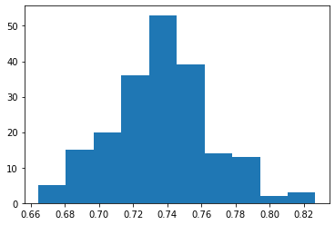

```
95.0 confidence interval 68.1% and 79.3%
```

```python
bootstrap("RandomForestClassifier", RandomForestClassifier(n_estimators=50), bf_df, 200)
```

```
AdaBoostClassifier
```

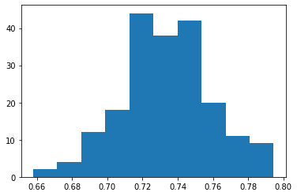

```
95.0 confidence interval 68.4% and 78.7%
```

```python
bootstrap("AdaBoostClassifier", AdaBoostClassifier(n_estimators=100, learning_rate=0.25, random_state=1), bf_df, 200)
```

```
XGBClassifier
```

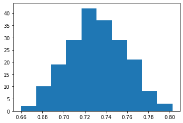

```
95.0 confidence interval 68.0% and 78.0%
```

```python
bootstrap("XGBClassifier", XGBClassifier(max_depth = 6, objective="multi:softmax", learning_rate = 0.1, gamma = 0.4), bf_df, 200)
```

## Design, train and test Neural networks classifiers

```python
# get the accuracy, precision, recall, f1 score from model
def get_classification_metrics(model, X_test, y_test, target_type):

  # predict probabilities for test set
  yhat_probs = model.predict(X_test, verbose=0) # Multiclass

  # predict crisp classes for test set
  if target_type == 'multi_class':
    yhat_classes = model.predict_classes(X_test, verbose=0) # Multiclass
  else:
    yhat_classes = (np.asarray(model.predict(X_test))).round() # Multilabel

  # reduce to 1d array
  yhat_probs = yhat_probs[:, 0]

  # accuracy: (tp + tn) / (p + n)
  accuracy = accuracy_score(y_test, yhat_classes)

  # precision tp / (tp + fp)
  precision = precision_score(y_test, yhat_classes, average='micro')

  # recall: tp / (tp + fn)
  recall = recall_score(y_test, yhat_classes, average='micro')

  # f1: 2 tp / (2 tp + fp + fn)
  f1 = f1_score(y_test, yhat_classes, average='micro')

  return accuracy, precision, recall, f1
```

```python
class Metrics(tf.keras.callbacks.Callback):

    def __init__(self, validation_data=()):
        super().__init__()
        self.validation_data = validation_data

    def on_train_begin(self, logs={}):
        self.val_f1s = []
        self.val_recalls = []
        self.val_precisions = []

    def on_epoch_end(self, epoch, logs={}):
        xVal, yVal, target_type = self.validation_data
        if target_type == 'multi_class':
          val_predict_classes = model.predict_classes(xVal, verbose=0) # Multiclass
        else:
          val_predict_classes = (np.asarray(self.model.predict(xVal))).round() # Multilabel


        val_targ = yVal

        _val_f1 = f1_score(val_targ, val_predict_classes, average='micro')
        _val_recall = recall_score(val_targ, val_predict_classes, average='micro')
        _val_precision = precision_score(val_targ, val_predict_classes, average='micro')
        self.val_f1s.append(_val_f1)
        self.val_recalls.append(_val_recall)
        self.val_precisions.append(_val_precision)
        #print("— train_f1: %f — train_precision: %f — train_recall %f" % (_val_f1, _val_precision, _val_recall))
        return
```

- we will create a classification model that uses categorical columns and tf-idf features from accident description and label encoded target variable. We can use simple densely connected neural networks to make predictions.

```python
#fix random seed for reproducibility
seed = 7
np.random.seed(seed)
tf.random.set_seed(seed)

# define the model
model = Sequential()
model.add(Dense(50, input_dim=X_train.shape[1], activation='relu', kernel_initializer='he_uniform'))
model.add(Dense(100, activation='relu', kernel_initializer='he_uniform'))
model.add(Dense(150, activation='relu', kernel_initializer='he_uniform'))
model.add(Dense(40, activation='relu', kernel_initializer='he_uniform'))
model.add(Dense(1, activation='linear'))

# compile the keras model
#opt = optimizers.Adam(lr=1e-3)
opt = SGD(learning_rate=0.001, momentum=0.9)
model.compile(loss='mse', optimizer=opt, metrics=['accuracy'])

# Use earlystopping
callback = tf.keras.callbacks.EarlyStopping(monitor='loss', patience=5, min_delta=0.001)
rlrp = ReduceLROnPlateau(monitor='val_loss', factor=0.0001, patience=5, min_delta=1E-4)

# fit the keras model on the dataset
training_history = model.fit(X_train, y_train, epochs=100, batch_size=8, verbose=1, validation_data=(X_test, y_test), callbacks=[rlrp])
```

```python
model.summary()
```

```
Model: "sequential"
_________________________________________________________________
 Layer (type)                Output Shape              Param #
=================================================================
 dense (Dense)               (None, 50)                5600

 dense_1 (Dense)             (None, 100)               5100

 dense_2 (Dense)             (None, 150)               15150

 dense_3 (Dense)             (None, 40)                6040

 dense_4 (Dense)             (None, 1)                 41

=================================================================
Total params: 31,931
Trainable params: 31,931
Non-trainable params: 0
_________________________________________________________________
```

```python
accuracy = model.evaluate(X_test, y_test, batch_size=8, verbose=0)
print('Test accuracy: %.2f' % (accuracy[1]*100))
```

```
Test accuracy: 72.62
```

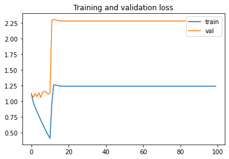

```python
epochs = range(len(training_history.history['loss'])) # Get number of epochs

# plot loss learning curves
plt.plot  (epochs, training_history.history['loss'], label = 'train')
plt.plot  (epochs, training_history.history['val_loss'], label = 'val')
plt.legend(loc = 'upper right')
plt.title ('Training and validation loss')
```

- We will create a classification model that uses categorical columns and tf-idf features from accident description and one-hot encoded target variable. We can use simple densely connected neural networks to make predictions.

```python
def reset_random_seeds():
   os.environ['PYTHONHASHSEED']=str(7)
   #np.random.seed(7)
   #random.seed(7)
   tf.random.set_seed(7)
```

```python
# fix random seed for reproducibility
reset_random_seeds()
#param = 1e-9
param = 1e-4

# define the model
model = Sequential()

model.add(Dense(10, input_dim=X_train.shape[1], activation='relu', kernel_initializer='he_uniform', kernel_regularizer=l2(param),
                kernel_constraint=unit_norm()))
model.add(Dropout(0.2))
model.add(BatchNormalization())
model.add(Dense(10, activation='relu', kernel_initializer='he_uniform', kernel_regularizer=l2(param),
                kernel_constraint=unit_norm()))
model.add(Dropout(0.5))
model.add(BatchNormalization())
model.add(Dense(5, activation='softmax', kernel_regularizer=l2(param),
                kernel_constraint=unit_norm())) # Multilabel

# compile the keras model
#opt = optimizers.Adamax(lr=0.01)
opt = SGD(learning_rate=0.001, momentum=0.9)
model.compile(loss='categorical_crossentropy', optimizer=opt, metrics=['categorical_accuracy'])

# Use earlystopping
callback = tf.keras.callbacks.EarlyStopping(monitor='loss', patience=7, min_delta=1E-3)
rlrp = ReduceLROnPlateau(monitor='val_loss', factor=0.0001, patience=5, min_delta=1E-4)

target_type = 'multi_label'
metrics = Metrics(validation_data=(X_train, y_train_dummy_target, target_type))

# fit the keras model on the dataset
training_history = model.fit(X_train, y_train_dummy_target, epochs=100, batch_size=8, verbose=1, validation_data=(X_test, y_test_dummy_target), callbacks=[rlrp, metrics])
```

```python
model.summary()
```

```
Model: "sequential_1"
_________________________________________________________________
 Layer (type)                Output Shape              Param #
=================================================================
 dense_5 (Dense)             (None, 10)                1120

 dropout (Dropout)           (None, 10)                0

 batch_normalization (BatchN  (None, 10)               40
 ormalization)

 dense_6 (Dense)             (None, 10)                110

 dropout_1 (Dropout)         (None, 10)                0

 batch_normalization_1 (Batc  (None, 10)               40
 hNormalization)

 dense_7 (Dense)             (None, 5)                 55

=================================================================
Total params: 1,365
Trainable params: 1,325
Non-trainable params: 40
_________________________________________________________________
```